# Interpersonal Accuracy of Thoughts, Affect, and Personality Traits

Murat Kezer

# Introduction

As the saying goes, “it takes two to tango,” and interpersonal perception might be considered the social-cognitive equivalent of such a complex dance between perceivers (who make interpersonal judgments) and targets (who are judged). Even very brief interpersonal interactions are rich exchanges where targets emit behavior and cues via numerous channels. Thus it follows that perceivers can and do form perceptions on a range of dimensions, varying from fleeting judgments about discrete and context-specific thoughts or feelings, to snapshot judgments that regard more global and enduring characteristics. For example, empathic accuracy researchers examine the accuracy of perceivers’ judgments of targets’ specific thoughts and feelings (Ickes, Stinson, Bissonette, & Garcia, 1990) or changes in ongoing affective states (Levenson & Ruef, 1992). Personality researchers examine the accuracy of perceivers’ judgments of targets’ traits (Funder & Colvin, 1997), as well as the accuracy of perceptions about how others judge one’s own traits (i.e., meta-perceptions; Kenny & DePaulo, 1993). Despite the numerous studies on interpersonal accuracy, to our knowledge, there is no study that investigated different types of interpersonal accuracy simultaneously. In other words, it is not clear whether interpersonal accuracy as well as components of accuracy (e.g., perceiver and target effects) for thoughts, affect, and personality traits are comparable.

In order to test this research question, participants were videotaped interacting with a partner during brief “getting-acquainted” conversations using a round-robin design where each person served as perceiver and target in multiple interactions. After interacting, people rated their partner’s personality traits, and dynamically changing affect and thoughts. In order to assess accuracy, each partner made parallel ratings about their own traits, affect, and thoughts. Measures of expressivity, social-threat sensitivity, and psychological adjustment were also collected at a later time point from the participants in order to explore whether these variables are related to interpersonal accuracy traits, affect, and thoughts.

# Method

## Participants

Undergraduates from the University of Oregon participated in this study in exchange for course credit. In total, 53 groups of four participated in this study, which resulted in a total of 212 participants (63.7% women; Mage = 20.17, SDage = 2.99; 68.4% Caucasian, 11.8% Asian, 5.7% Black, 5.7% Hispanic, 8.4% other or missing). Participants were asked not to sign up for the study with friends so the partners were generally unacquainted.

## Measures

### Trait judgments

Participants rated their own and their partners’ personality trait ratings using a 21-item shortened version of the Big Five Inventory (BFI; John & Srivastava, 1999) using a 7-point Likert scale (1 = strongly disagree, 7 = strongly agree). Three additional items were included to assess intelligence (e.g., “Receives very good grades”). Two additional items were included to assess honesty (e.g., “Is trustworthy”).

### Affect judgments

In the target phase, participants reported their moment-by-moment affect following established procedures (Zaki et al., 2008) for the first two minutes of each video. To do this, participants watched each video and continuously rated the level of positive to negative affect they remember feeling at each moment using a sliding 9-point scale (1 = very negative, 9 = very positive) that was presented onscreen immediately below the video clip. Participants were instructed to use their mouse to “rate how you felt at each moment” and adjust the sliding scale as often as necessary. The computer recorded 10 samples per second that were averaged to provide a single affect rating for each second. In the perceiver phase, participants rated their partner’s moment-by-moment affect for the first two minutes of each video.

### Thought judgments

In the target phase, participants were asked to report the specific discrete, dynamic thoughts they remember having when the interaction took place following the Ickes methodology for assessing empathic accuracy for thoughts (Ickes et al., 1990). To ensure an adequate number of thoughts were reported, the videos were stopped at five pre-determined times (2:00, 2:45, 3:30, 4:15, 5:00) as opposed to freely allowing participants to indicate when they remembered having had a thought (see Verhofstadt, Buysse, Ickes, Davis, & Devoldre, 2008 for a similar variation on the original empathic accuracy paradigm). In the perceiver phase, participants were asked to guess their partner’s specific thoughts at each of the pre-determined tape stops. To code perceivers’ accuracy for targets’ specific thoughts, independent raters compared each participant’s inference to the actual thought reported by the target. The inferences were coded for accuracy using a 4-point scale (0 = essentially different content, 1 = somewhat correct content, but something notable is missing or incorrect, 2 = mostly correct content, but some small element is missing or incorrect, and 3 = essentially the same content). The coding was split into four batches and four to five independent raters coded each batch. The raters were reliable (Cronbach’s alpha ranges .91 to .92) thus accuracy ratings were averaged across raters for each inference and rescaled to yield a scale ranging from 0 (zero accuracy) to 100 (complete accuracy).

### Thought judgment baseline accuracy scores

Also following Ickes et al. (1990), we estimated baseline accuracy for perceivers’ thought judgments. Baseline accuracy refers to the overlap between the content of perceivers’ inferences and targets’ thoughts that is due to general knowledge (of a target or of the whole target pool), rather than distinctive knowledge of one specific thought. To estimate between-target baseline accuracy, three inferences were randomly selected for each perceiver from each target they interacted with. Each inference was then paired with different randomly selected thoughts reported by different targets from different groups. These pairings were rated for accuracy (using the same 4-point scale as above) by three judges. Accuracy ratings for each inference were averaged across judges (Cronbach’s α = .64).

### Expressivity

Participants completed the following measures of constructs related to expressivity: the Masking Scale (13 items; Gross & John, 1998), the Berkeley Expressivity Questionnaire (16 items; Gross & John, 1995), and the Emotion Regulation Questionnaire (10 items; Gross & John, 2003). The BEQ is comprised of three subscales that assess positive expressivity, negative expressivity, and impulse strength. The ERQ is comprised of two subscales that assess two types of emotion regulation, expressive suppression and cognitive reappraisal, although only the expressive suppression subscale was of interest as a potential correlate of readability. The Extraversion subscale of the Big Five Inventory (BFI; John & Srivastava, 1999) which was used to assess trait judgments (see description below) was also computed as a potential component of expressivity that might relate to target readability.

### Social-threat sensitivity

Participants completed the following measures of constructs related to social-threat sensitivity: the Need to Belong Scale (10 items; Leary, Kelly, Cottrell, & Schreindorfer, 2005), the UCLA Loneliness Scale (20 items; Russell, 1996), and the Fear of Negative Evaluation Scale (12 items; Leary, 1983). Participants completed the Social Interaction Anxiety Scale (6 items; Peters, Sunderland, Andrews, Rapee, & Mattick, 2012) which is comprised of two subscales that assess social anxiety and social phobia. Participants completed the Attachment Style Measure (13 items; Simpson, 1990) which is comprised of three subscales that assess the three prototypical types of attachment: secure, anxious, and avoidant (note that these are not categorical and treated continuously). In keeping with the direction of the other two subscales, the items comprising the secure attachment subscale were coded such that higher values indicate less secure attachment.

### Psychological adjustment

Participants completed the following measures of constructs related to psychological adjustment: the Authenticity Scale (12 items; Wood, Linley, Maltby, Baliousis, & Joseph, 2008), the Rosenberg Self-Esteem Scale (10 items; Rosenberg, 1965), the Satisfaction with Life Scale (5 items; Diener, Emmons, Larsen, & Griffin, 1985), and the Sense of Power Scale (8 items; Anderson, John, & Keltner, 2012).

## Procedure

### Phase II

After all possible dyads had interacted, everyone in the group was separated to private cubicles that were each equipped with a computer and headphones. Participants (now acting as targets) watched each of the three videos of the dyadic interactions they participated in. For the first two minutes of each video, participants were asked to report their moment-by-moment affect (see details below). At the end of the first two minutes and at the end of each 45 second period thereafter, the video was paused and participants were asked to report the specific thoughts they remembered having at that time (see details below). It was stressed that participants should report the affect and thoughts they remembered having experienced during the original interaction and not any affect or thoughts they experienced in reaction to viewing the videotapes. Next participants (now acting as perceivers) again watched each of the three videos of the dyadic interactions they participated in. However, this time they continuously rated the affect of their partner for the first two minutes of the video and inferred their partner’s thoughts at each of the pre-determined tape stops.

## Analytical strategy

### Trait judgment

Trait judgment accuracy was modeled using the Social Accuracy Model (SAM; Biesanz, 2010). SAM was developed for trait judgment research and is appropriate when perceivers make judgments of a target across some series of attributes (e.g., multiple personality trait items). SAM simultaneously models perceivers’ judgments as a function of the criterion measure (e.g., a specific target’s self-reported extraversion) and the mean for the criterion measure (e.g., the average level of self-reported extraversion). As a result, the raw profile relationship is decomposed into distinctive accuracy (the correspondence between perceivers’ judgments and targets’ self-reports controlling for the average person’s personality) and normative accuracy (the correspondence between perceivers judgments’ and the average person’s personality after controlling for targets’ self-reports).

### Affect accuracy

The continuous affect ratings were first binned (following Zaki et al., 2008) by calculating a non-moving average for each five-second interval. Each binned interval served as one data point. Affect accuracy was also modeled using SAM: perceivers’ affect judgments were predicted by targets’ actual affect ratings as well as average affect ratings. This is a novel application of SAM that has not yet been tested. However, because there may be a general affect trajectory that the modal dyadic interaction follows (e.g., people may start out feeling awkward but gradually warm to each other and thus affect follows a roughly upward linear trajectory), it is possible that affect accuracy could be broken down into normative and distinctive accuracy much like trait judgments.

### Thought accuracy

These data were modeled using the Social Relations Model (SRM; Kashy & Kenny, 1990; Kenny & LaVoie, 1985) which was developed for round-robin designs where interpersonal perceptions are measured. The SRM is also a cross-classified multilevel modeling strategy that breaks down a rating (in this case an accuracy score) as a function of the group mean, a perceiver effect, a target effect and a dyadic relationship effect. For example, Polly’s empathic accuracy for Tim is a function of their group mean3, the extent to which Polly is generally accurate at reading others’ thoughts, the extent to which Tim’s thoughts are generally accurately perceived by others, and Polly’s unique accuracy for Tim above and beyond the other main effects.

Similar to decomposing overall accuracy into normative and distinctive components in the SAM analyses, baseline accuracy scores were calculated (see above for details) in order to estimate how much of the perceivers’ overall thought accuracy is attributable to making correct inferences based on general knowledge and/or stereotypes. Empathic accuracy scores were divided into normative (baseline accuracy) and distinctive accuracy (overall accuracy corrected for baseline accuracy) and SRM analyses were conducted on each component separately.

# Results and Discussion

## Descriptive statistics

Table 1 represents descriptive statistics as well as internal consistency metrics (i.e., alpha and omega) for predictors of interpersonal accuracy.

```r
kable_style(table1,
            title = "<center><b>Table 1: Descriptive Statistics and Internal Consistency</center></b>")
```

**Table 1: Descriptive Statistics and Internal Consistency**

| Variables | N_Valid | Mean | SD | Min | Max | Alpha | Omega |
| --- | --- | --- | --- | --- | --- | --- | --- |
| Rapport | 208 | 58.80 | 9.94 | 14.29 | 80.00 | 0.87 | 0.89 |
| Insecure Attachment | 183 | 44.72 | 13.73 | 13.33 | 90.00 | 0.52 | 0.56 |
| Avoidant Attachment | 183 | 32.95 | 14.74 | 4.17 | 70.83 | 0.81 | 0.82 |
| Anxious Attachment | 183 | 24.80 | 19.89 | 0.00 | 83.33 | 0.47 | 0.57 |
| Authenticity | 183 | 71.65 | 13.84 | 18.06 | 94.44 | 0.87 | 0.87 |
| Masking | 182 | 33.15 | 14.54 | 3.85 | 69.23 | 0.83 | 0.84 |
| Need to Belong | 182 | 52.02 | 14.78 | 16.67 | 86.67 | 0.82 | 0.83 |
| Loneliness | 183 | 34.78 | 15.58 | 15.00 | 73.33 | 0.94 | 0.94 |
| Fear of Negative Evaluation | 183 | 40.82 | 21.61 | 0.00 | 83.33 | 0.96 | 0.96 |
| Positive Expressivity | 183 | 57.35 | 14.27 | 16.67 | 83.33 | 0.74 | 0.76 |
| Negative Expressivity | 183 | 46.42 | 16.20 | 11.11 | 91.67 | 0.74 | 0.75 |
| Impulse Strength | 183 | 47.25 | 18.21 | 0.00 | 83.33 | 0.82 | 0.83 |
| Supression | 182 | 28.38 | 17.51 | 0.00 | 66.67 | 0.74 | 0.75 |
| Reappraisal | 182 | 49.51 | 16.75 | 0.00 | 83.33 | 0.88 | 0.89 |
| Self-Esteem | 183 | 66.61 | 16.28 | 20.00 | 91.67 | 0.90 | 0.91 |
| Satisfaction with Life | 183 | 49.16 | 19.30 | 0.00 | 83.33 | 0.86 | 0.87 |
| Sense of Power | 183 | 62.35 | 13.11 | 22.92 | 89.58 | 0.83 | 0.84 |
| Social Interaction Anxiety | 183 | 17.17 | 16.52 | 0.00 | 72.22 | 0.85 | 0.85 |
| Social Phobia | 183 | 18.62 | 18.66 | 0.00 | 83.33 | 0.89 | 0.89 |
| Perceiver Openness to Experience | 207 | 70.41 | 16.04 | 25.00 | 100.00 | 0.39 | 0.39 |
| Perceiver Conscientiousness | 207 | 73.35 | 13.84 | 12.50 | 100.00 | 0.65 | 0.73 |
| Perceiver Extraversion | 207 | 60.56 | 17.92 | 14.29 | 95.24 | 0.83 | 0.84 |
| Perceiver Agreeableness | 207 | 71.96 | 14.10 | 29.17 | 100.00 | 0.57 | 0.58 |
| Perceiver Neuroticism | 207 | 41.81 | 18.08 | 0.00 | 87.50 | 0.69 | 0.71 |
| Perceiver Intelligence | 207 | 74.72 | 12.96 | 16.67 | 100.00 | 0.62 | 0.68 |
| Perceiver Trustworthiness | 207 | 87.40 | 10.67 | 33.33 | 100.00 | 0.63 | 0.63 |

## Variance decomposition

Table 2 represents the null models, and Figure 1 represents the ICCs across domains.

```r
null_models <- df_list %>%
  map_dfr(
    ~ lmer(judgment ~ (1|perceiver_id) +
             (1|target_id) +
             (1|dyad_id),
           data = .x) %>%
      broom.mixed::tidy()
    )

null_models %>%
  kable_style(title = "<center><b>Table 2. Null Models</b></center>") %>%
  kableExtra::pack_rows("Personality", 1, 5) %>%
  kableExtra::pack_rows("Affect", 6, 10) %>%
  kableExtra::pack_rows("Thought", 11, 15)
```

**Table 2. Null Models**

| effect | group | term | estimate | std.error | statistic | df | p.value |
| --- | --- | --- | --- | --- | --- | --- | --- |
| **Personality** |  |  |  |  |  |  |  |
| fixed | NA | (Intercept) | 4.58 | 0.02 | 202.05 | 221.11 | 0 |
| ran_pars | dyad_id | sd__(Intercept) | 0.06 | NA | NA | NA | NA |
| ran_pars | target_id | sd__(Intercept) | 0.11 | NA | NA | NA | NA |
| ran_pars | perceiver_id | sd__(Intercept) | 0.26 | NA | NA | NA | NA |
| ran_pars | Residual | sd__Observation | 1.44 | NA | NA | NA | NA |
| **Affect** |  |  |  |  |  |  |  |
| fixed | NA | (Intercept) | 5.90 | 0.06 | 92.94 | 364.76 | 0 |
| ran_pars | dyad_id | sd__(Intercept) | 0.63 | NA | NA | NA | NA |
| ran_pars | target_id | sd__(Intercept) | 0.67 | NA | NA | NA | NA |
| ran_pars | perceiver_id | sd__(Intercept) | 0.32 | NA | NA | NA | NA |
| ran_pars | Residual | sd__Observation | 1.12 | NA | NA | NA | NA |
| **Thought** |  |  |  |  |  |  |  |
| fixed | NA | (Intercept) | 21.35 | 0.72 | 29.62 | 178.82 | 0 |
| ran_pars | dyad_id | sd__(Intercept) | 5.95 | NA | NA | NA | NA |
| ran_pars | target_id | sd__(Intercept) | 2.97 | NA | NA | NA | NA |
| ran_pars | perceiver_id | sd__(Intercept) | 4.79 | NA | NA | NA | NA |
| ran_pars | Residual | sd__Observation | 11.15 | NA | NA | NA | NA |

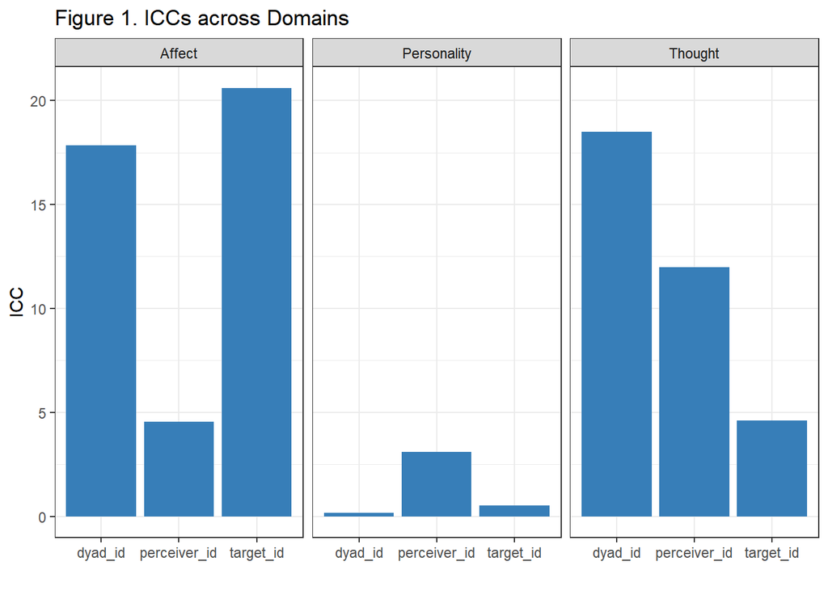

```r
null_models2 <- df_list %>%
  map(
    ~ lmer(judgment ~ (1|perceiver_id) +
             (1|target_id) +
             (1|dyad_id),
           data = .x)
    )

iccs <-
map_dfr(null_models2, performance::icc, by_group = TRUE) %>%
  mutate(model = c(rep("Personality", 3),
                   rep("Affect", 3),
                   rep("Thought", 3)),
         ICC = ICC*100)

iccs %>%
  ggplot() +
  geom_col(aes(Group, ICC), fill = "#377eb8") +
  labs(title = "Figure 1. ICCs across Domains",
       x = "") +
  facet_wrap(~model) +
  theme_bw()
```

## Interpersonal accuracy

All analyses were conducted in R’s lme4 package (Bates et al., 2013).

```r
# for looping purposes
df_personality_self <-
  df_personality %>%
  select(perceiver_id:judgment,
         norm = self_norm,
         distinct = self_dist)

df_personality_inf <-
  df_personality %>%
  select(perceiver_id:judgment,
         norm = inf_norm,
         distinct = inf_dist)

df_affect <-
  df_affect %>%
  rename(distinct = self_dist)

df_list2 <- list(df_personality_self,
                 df_personality_inf,
                 df_affect)

# models
models_norm_distinct <-
  map_dfr(df_list2, ~

            lmer(judgment ~ distinct + norm +
                   (1|perceiver_id) +
                   (1|target_id) +
                   (1|dyad_id),
                 data = .x) %>%

        broom.mixed::tidy()
          )

# Accuracy for thoughts is a little different. So, we'll only have two null models for distinctive and normative accuracy for thoughts. See the methods section for details.

models_norm_distinct_thoughts <-
  df_thought %>%
  rename(Normative = BaselineEA100,
         Distinctive = CrrctdEAnoneg) %>%
  pivot_longer(cols = c(Normative, Distinctive),
               names_to = "DVs",
               values_to = "rating") %>%
  split(., .$DVs) %>%
  map(., ~

        lmer(rating ~
               (1|perceiver_id) +
               (1|target_id) +
               (1|dyad_id),
             data = .x)

        )

map_dfr(models_norm_distinct_thoughts, isSingular) %>%
  kable_style(title = "<center><b>Are the models for thought accuracy singular?</b></center>")
```

**Are the models for thought accuracy singular?**

| Distinctive | Normative |
| --- | --- |
| FALSE | TRUE |

```r
model_norm_thought <- lmer(BaselineEA100 ~
                             (1|perceiver_id),
                           data = df_thought) %>% broom.mixed::tidy()

model_dist_thought <- lmer(CrrctdEAnoneg ~
                             (1|perceiver_id) +
                             (1|target_id) +
                             (1|dyad_id),
                           data = df_thought) %>% broom.mixed::tidy()
```

```r
bind_rows(models_norm_distinct,
          model_norm_thought,
          model_dist_thought) %>%
  kable_style(title = "<center><b>Table 3. Normative and Distinctive Accuracy</b></center>") %>%
  kableExtra::pack_rows("Self-reported Personality", 1, 7) %>%
  kableExtra::pack_rows("Informant-reported Personality", 8, 14) %>%
  kableExtra::pack_rows("Affect", 15, 21) %>%
  kableExtra::pack_rows("Normative Thought", 22, 24) %>%
  kableExtra::pack_rows("Distinctive Thought", 25, 29)
```

**Table 3. Normative and Distinctive Accuracy**

| effect | group | term | estimate | std.error | statistic | df | p.value |
| --- | --- | --- | --- | --- | --- | --- | --- |
| **Self-reported Personality** |  |  |  |  |  |  |  |
| fixed | NA | (Intercept) | 4.58 | 0.02 | 193.71 | 250.24 | 0.00 |
| fixed | NA | distinct | 0.13 | 0.01 | 16.74 | 15154.58 | 0.00 |
| fixed | NA | norm | 0.78 | 0.01 | 76.72 | 15323.38 | 0.00 |
| ran_pars | dyad_id | sd__(Intercept) | 0.12 | NA | NA | NA | NA |
| ran_pars | perceiver_id | sd__(Intercept) | 0.27 | NA | NA | NA | NA |
| ran_pars | target_id | sd__(Intercept) | 0.13 | NA | NA | NA | NA |
| ran_pars | Residual | sd__Observation | 1.22 | NA | NA | NA | NA |
| **Informant-reported Personality** |  |  |  |  |  |  |  |
| fixed | NA | (Intercept) | 4.59 | 0.03 | 160.48 | 151.51 | 0.00 |
| fixed | NA | distinct | -0.01 | 0.01 | -1.30 | 9918.63 | 0.19 |
| fixed | NA | norm | 0.62 | 0.01 | 65.99 | 9797.46 | 0.00 |
| ran_pars | dyad_id | sd__(Intercept) | 0.13 | NA | NA | NA | NA |
| ran_pars | target_id | sd__(Intercept) | 0.13 | NA | NA | NA | NA |
| ran_pars | perceiver_id | sd__(Intercept) | 0.26 | NA | NA | NA | NA |
| ran_pars | Residual | sd__Observation | 1.21 | NA | NA | NA | NA |
| **Affect** |  |  |  |  |  |  |  |
| fixed | NA | (Intercept) | 5.90 | 0.06 | 91.90 | 366.70 | 0.00 |
| fixed | NA | distinct | 0.06 | 0.00 | 13.09 | 69499.76 | 0.00 |
| fixed | NA | norm | 1.43 | 0.02 | 73.50 | 69888.81 | 0.00 |
| ran_pars | dyad_id | sd__(Intercept) | 0.61 | NA | NA | NA | NA |
| ran_pars | target_id | sd__(Intercept) | 0.67 | NA | NA | NA | NA |
| ran_pars | perceiver_id | sd__(Intercept) | 0.36 | NA | NA | NA | NA |
| ran_pars | Residual | sd__Observation | 1.08 | NA | NA | NA | NA |
| **Normative Thought** |  |  |  |  |  |  |  |
| fixed | NA | (Intercept) | 3.98 | 0.27 | 14.56 | 187.41 | 0.00 |
| ran_pars | perceiver_id | sd__(Intercept) | 1.81 | NA | NA | NA | NA |
| ran_pars | Residual | sd__Observation | 5.59 | NA | NA | NA | NA |
| **Distinctive Thought** |  |  |  |  |  |  |  |
| fixed | NA | (Intercept) | 17.96 | 0.72 | 25.01 | 178.40 | 0.00 |
| ran_pars | dyad_id | sd__(Intercept) | 6.27 | NA | NA | NA | NA |
| ran_pars | target_id | sd__(Intercept) | 2.21 | NA | NA | NA | NA |
| ran_pars | perceiver_id | sd__(Intercept) | 4.62 | NA | NA | NA | NA |
| ran_pars | Residual | sd__Observation | 11.38 | NA | NA | NA | NA |

## Predictors of interpersonal accuracy

```r
tabl4 %>%
  select(-Domain) %>%
  kable_style(title = "<center><b>Predictors of Interpersonal Accuracy</b></center>") %>%
  kableExtra::pack_rows("Personality", 1, 208) %>%
  kableExtra::pack_rows("Affect", 209, 416) %>%
  kableExtra::pack_rows("Normative Thought", 417, 520) %>%
  kableExtra::pack_rows("Distinctive Thought", 521, 676) %>%
  kableExtra::scroll_box(height = "1000px")
```

**Predictors of Interpersonal Accuracy**

| Predictors | effect | group | term | estimate | std.error | statistic | df | p.value |
| --- | --- | --- | --- | --- | --- | --- | --- | --- |
| **Personality** |  |  |  |  |  |  |  |  |
| Agree_c | fixed | NA | (Intercept) | 4.58 | 0.02 | 200.01 | 217.78 | <0.001 |
| Agree_c | fixed | NA | value | 0.00 | 0.00 | 0.92 | 202.70 | 0.358 |
| Agree_c | fixed | NA | value:self_norm | 0.01 | 0.00 | 11.52 | 15306.99 | <0.001 |
| Agree_c | fixed | NA | value:self_dist | 0.00 | 0.00 | -1.56 | 15541.56 | 0.118 |
| Agree_c | ran_pars | dyad_id | sd__(Intercept) | 0.06 | NA | NA | NA | NA |
| Agree_c | ran_pars | target_id | sd__(Intercept) | 0.10 | NA | NA | NA | NA |
| Agree_c | ran_pars | perceiver_id | sd__(Intercept) | 0.26 | NA | NA | NA | NA |
| Agree_c | ran_pars | Residual | sd__Observation | 1.44 | NA | NA | NA | NA |
| AnxAtt_c | fixed | NA | (Intercept) | 4.60 | 0.02 | 190.97 | 192.44 | <0.001 |
| AnxAtt_c | fixed | NA | value | 0.00 | 0.00 | 0.37 | 181.34 | 0.715 |
| AnxAtt_c | fixed | NA | value:self_norm | 0.00 | 0.00 | -3.43 | 13527.60 | <0.001 |
| AnxAtt_c | fixed | NA | value:self_dist | 0.00 | 0.00 | 2.15 | 13797.03 | 0.032 |
| AnxAtt_c | ran_pars | dyad_id | sd__(Intercept) | 0.07 | NA | NA | NA | NA |
| AnxAtt_c | ran_pars | target_id | sd__(Intercept) | 0.09 | NA | NA | NA | NA |
| AnxAtt_c | ran_pars | perceiver_id | sd__(Intercept) | 0.26 | NA | NA | NA | NA |
| AnxAtt_c | ran_pars | Residual | sd__Observation | 1.44 | NA | NA | NA | NA |
| Authenticity_c | fixed | NA | (Intercept) | 4.60 | 0.02 | 190.97 | 192.77 | <0.001 |
| Authenticity_c | fixed | NA | value | 0.00 | 0.00 | -0.92 | 178.47 | 0.361 |
| Authenticity_c | fixed | NA | value:self_norm | 0.01 | 0.00 | 6.61 | 13528.27 | <0.001 |
| Authenticity_c | fixed | NA | value:self_dist | 0.00 | 0.00 | 0.24 | 13748.84 | 0.812 |
| Authenticity_c | ran_pars | dyad_id | sd__(Intercept) | 0.07 | NA | NA | NA | NA |
| Authenticity_c | ran_pars | target_id | sd__(Intercept) | 0.09 | NA | NA | NA | NA |
| Authenticity_c | ran_pars | perceiver_id | sd__(Intercept) | 0.26 | NA | NA | NA | NA |
| Authenticity_c | ran_pars | Residual | sd__Observation | 1.44 | NA | NA | NA | NA |
| AvoAtt_c | fixed | NA | (Intercept) | 4.60 | 0.02 | 190.44 | 193.05 | <0.001 |
| AvoAtt_c | fixed | NA | value | 0.00 | 0.00 | -0.32 | 180.80 | 0.752 |
| AvoAtt_c | fixed | NA | value:self_norm | 0.00 | 0.00 | -7.29 | 13526.91 | <0.001 |
| AvoAtt_c | fixed | NA | value:self_dist | 0.00 | 0.00 | -0.68 | 13782.39 | 0.495 |
| AvoAtt_c | ran_pars | dyad_id | sd__(Intercept) | 0.07 | NA | NA | NA | NA |

[output cut: 650 more lines]

# Author Note

“This project was completed by Dr. Karyn Lewis in 2014. Introduction and method sections are mostly copied from Dr. Lewis’ dissertation, which were adapted and edited for the current project.”